# Soc722 - SR Chapter 2

Turgut Keskintürk

2022-09-23

Hello there! Let’s start with our exercises for McElreath’s *Statistical Rethinking*, Chapter 2.

# 1 Set-Up

```r
# load the relevant packages
library(tidyverse) # I hided the output. So ugly!
```

# 2 Responses to Questions

## 2.1 Easy Problems

**2E1**. (2): Pr(rain|Monday) and (4) Pr(rain|Monday)/Pr(Monday) are equal to the statement.

**2E2**. (3): The probability that it is Monday, given that it is raining.

**2E3**. (1): Pr(Monday|rain) and (4) Pr(Monday|rain) Pr(rain)/ Pr(Monday) are equal to the statement.

**2E4**. The statement “the probability of water is 0.7” means that if I randomly pick a spot in the globe, I have a 7 in 10 chance that the spot is water. This means that probability describes a relation of uncertainty, rather than an objective reality.

## 2.2 Medium Problems

**2M1**. In this question, we are going to compute grid approximate posterior distributions for some sets of observations. We will assume a uniform prior for each case. Let us begin.

Part (1): W, W, W.

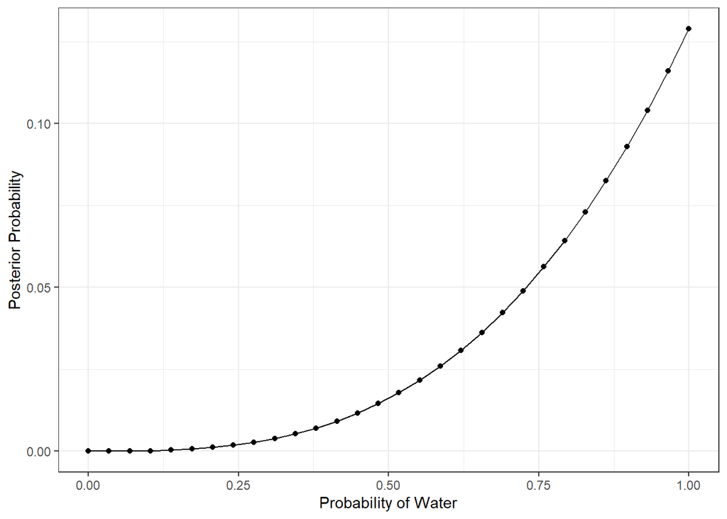

```r
d <-
  tibble(grid = seq(
    from = 0,
    to = 1,
    length.out = 30
  ),
  # I love 30, it's probably a frequentist thing, no? :)
  prior = 1) %>%
  mutate(likelihood = dbinom(3, size = 3, prob = grid)) %>%
  mutate(posterior = likelihood * prior) %>%
  mutate(posterior_std = posterior / sum(posterior))

d %>%
  ggplot(aes(x = grid, y = posterior_std)) +
  geom_point() + geom_line() +
  labs(x = "Probability of Water", y = "Posterior Probability") +
  theme_bw()
```

Part (2): W, W, W, L.

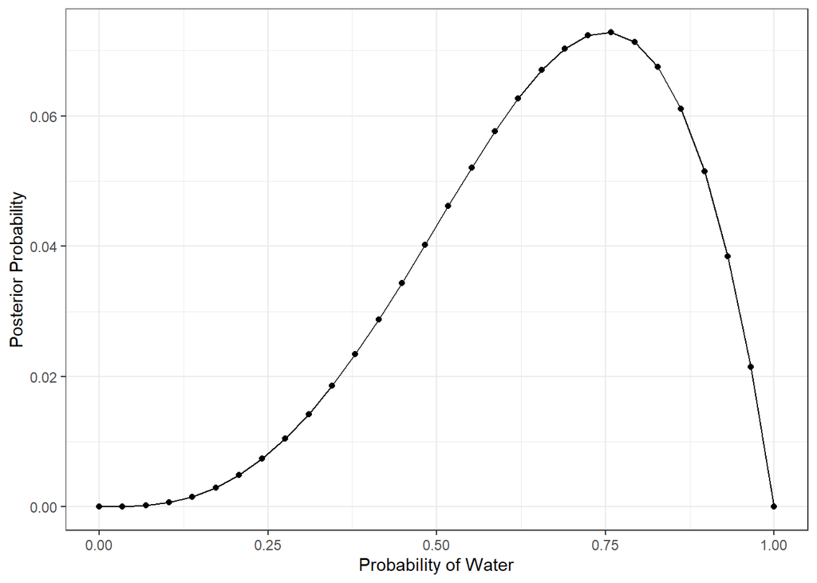

```r
d <-
  tibble(grid = seq(
    from = 0,
    to = 1,
    length.out = 30
  ),
  prior = 1) %>%
  mutate(likelihood = dbinom(3, size = 4, prob = grid)) %>%
  mutate(posterior = likelihood * prior) %>%
  mutate(posterior_std = posterior / sum(posterior))


d %>%
  ggplot(aes(x = grid, y = posterior_std)) +
  geom_point() + geom_line() +
  labs(x = "Probability of Water", y = "Posterior Probability") +
  theme_bw()
```

Part (3): L, W, W, L, W, W, W.

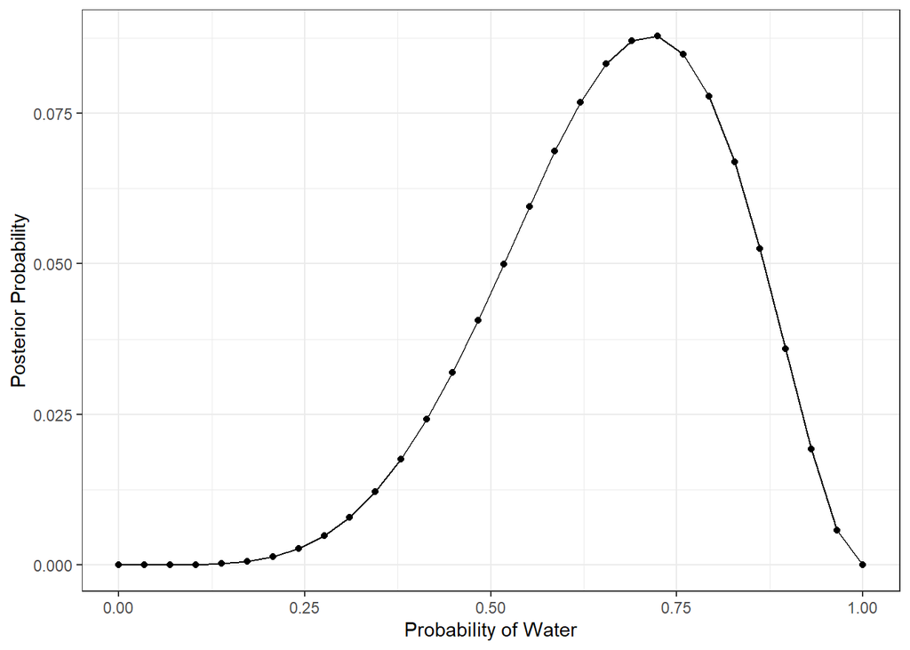

```r
d <-
  tibble(grid = seq(
    from = 0,
    to = 1,
    length.out = 30
  ),
  prior = 1) %>%
  mutate(likelihood = dbinom(5, size = 7, prob = grid)) %>%
  mutate(posterior = likelihood * prior) %>%
  mutate(posterior_std = posterior / sum(posterior))

d %>%
  ggplot(aes(x = grid, y = posterior_std)) +
  geom_point() + geom_line() +
  labs(x = "Probability of Water", y = "Posterior Probability") +
  theme_bw()
```

**2M2**. OK, now we assume a prior = 0 if p < 0.5, and a positive *c* if p >= 0.5. Same computations and plotting for same set of thingies. In order to do that, I am going to create some logical conditions for the prior.

Part (1): W, W, W.

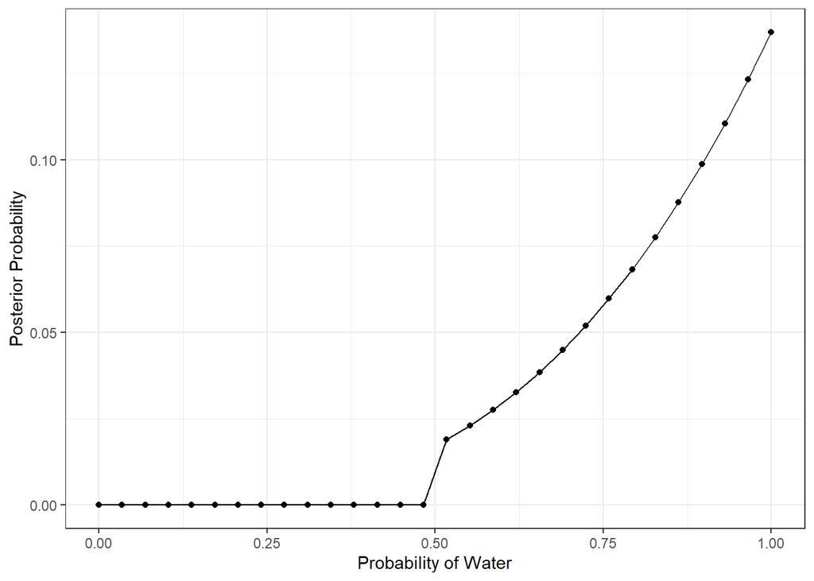

```r
d <-
  tibble(grid = seq(
    from = 0,
    to = 1,
    length.out = 30
  ),
  prior = ifelse(grid < 0.5, 0, 1)) %>%
  mutate(likelihood = dbinom(3, size = 3, prob = grid)) %>%
  mutate(posterior = likelihood * prior) %>%
  mutate(posterior_std = posterior / sum(posterior))

d %>%
  ggplot(aes(x = grid, y = posterior_std)) +
  geom_point() + geom_line() +
  labs(x = "Probability of Water", y = "Posterior Probability") +
  theme_bw()
```

Part (2): W, W, W, L.

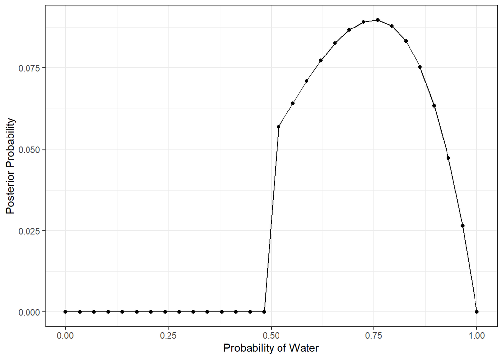

```r
d <-
  tibble(grid = seq(
    from = 0,
    to = 1,
    length.out = 30
  ),
  prior = ifelse(grid < 0.5, 0, 1)) %>%
  mutate(likelihood = dbinom(3, size = 4, prob = grid)) %>%
  mutate(posterior = likelihood * prior) %>%
  mutate(posterior_std = posterior / sum(posterior))

d %>%
  ggplot(aes(x = grid, y = posterior_std)) +
  geom_point() + geom_line() +
  labs(x = "Probability of Water", y = "Posterior Probability") +
  theme_bw()
```

Part (3): L, W, W, L, W, W, W.

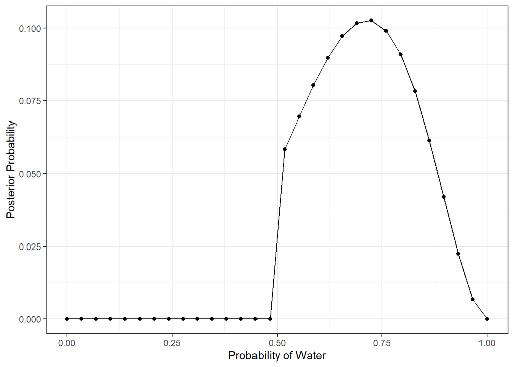

```r
d <-
  tibble(grid = seq(
    from = 0,
    to = 1,
    length.out = 30
  ),
  prior = ifelse(grid < 0.5, 0, 1)) %>%
  mutate(likelihood = dbinom(5, size = 7, prob = grid)) %>%
  mutate(posterior = likelihood * prior) %>%
  mutate(posterior_std = posterior / sum(posterior))

d %>%
  ggplot(aes(x = grid, y = posterior_std)) +
  geom_point() + geom_line() +
  labs(x = "Probability of Water", y = "Posterior Probability") +
  theme_bw()
```

Nice!

**2M3**. OK, we are going to use the Bayes here! What we want to know is Pr(Earth|Land).

We can write the following rule:

$$Pr(Earth|Land) = \frac{Pr(Land|Earth)*Pr(Earth)}{Pr(Land)}$$

We know that Pr(Land|Earth) is 0.3. We also assumed that Pr(Earth) is 0.5. All we want to know is the Pr(Land), which is calculated as:

$$Pr(Land) = Pr(Land|Earth)*Pr(Earth) + Pr(Land|Mars)*Pr(Mars)$$

Let’s do the math:

```r
0.3 * 0.5 / (0.3*0.5 + 1*0.5)
```

```
## [1] 0.2307692
```

Ta daa! Bayes rules!

**2M4**. Three cards, two sides, either black or white, but different compositions. This is the pattern: BB, BW, WW. First run: black side. The probability of the other side is also black is 2/3. How? OK, let’s count the ways this can happen:

- There are three ways to produce 1 black side:
  - Pr(1BlackSide) = 3/6
- There are two ways to produce 2 black sides (warning: order matters!).
  - Pr(2BlackSide) = 1/3

OK, we can apply Bayes Rule once again.

$$Pr(2BlackSide|1BlackSide) =
\frac{Pr(1BlackSide|2BlackSide)*Pr(2BlackSide)}{Pr(1BlackSide)}$$
Well, the first is obviously 1, and the second term is 1/3. The denominator is 1/2.

```r
(1 * 1/3) / 0.5
```

```
## [1] 0.6666667
```

*But*, we can also simply count the ways in which all possibilities can happen. Think about the total number of times a black can come up. It is three. And now, think about the ways in which both sides can come up black. It is two. Thus, the answer is 2/3.

**2M5**. We have four cards now: BB, BB, BW, WW. OK, this changes the number of possibilities.

Let’s count the times a black card can face up:

| Cards | Ways |
| --- | --- |
| BB | 2 |
| BW | 1 |
| BB | 2 |
| WW | 0 |

So, both sides BB, given that there is at least one B is 4/5 = 0.8.

Bayes will give you the same answer, too.

**2M6**. We now have another condition: it is less likely to pick up a black card. We have three cards: BB, BW, WW. Let’s count the ways.

| Cards | Possible Weights | Priors | Likelihoods |
| --- | --- | --- | --- |
| BB | 2 | 1 | 2 |
| BW | 1 | 2 | 2 |
| WW | 0 | 3 | 0 |

Pr(BB) = BB / (BB + BW) = 2 / (2 + 2) = 0.5.

**2M7**. OK, same set-up, but we have now the second card with W on its side. We are gonna make some updating!

If the first card is BB, there could be three ways for the second card to be White. If the first card is BW, there could be 2 ways for the second card to be white. The first count could not be WW, so we cross that possibility.

| Cards | First Count | Second Count | New Count |
| --- | --- | --- | --- |
| BB | 2 | 3 | 2 x 3 = 6 |
| BW | 1 | 2 | 1 x 2 = 2 |
| WW | 0 | 0 | 0 |

Out of 8 possibilities, 6 can be BB. Thus 6/8 = 0.75.

## 2.3 Hard Problems

**2H1**. OK, let’s go with the facts first:

- Pr(SpeciesA) = 0.5.
- Pr(SpeciesB) = 0.5.
- Pr(Twins|SpeciesA) = 0.1.
- Pr(Twins|SpeciesB) = 0.2.

We want to understand the probability of the first birth being twins.

$$P(Twins) = Pr(SpeciesA) * Pr(Twins|SpeciesA) + Pr(SpeciesB) *
Pr(Twins|SpeciesB)$$

So, the probability of first birth being twins is `0.5*0.1 + 0.5*0.2 =` **0.15**.

OK, this is important. Why? We now have an information pertaining to which one of these species is more likely. After all, if Species A and B have different probabilities of giving birth to twins, the information that we have twins should update our prior belief.

How? We now do not have to assume that Pr(SpeciesA) and Pr(SpeciesB) are 0.50. Let’s update.

$$Pr(SpeciesA|Twins) = \frac{Pr(Twins|SpeciesA)*Pr(SpeciesA)}{Pr(Twins)}
\\
Pr(SpeciesB|Twins) = \frac{Pr(Twins|SpeciesB)*Pr(SpeciesB)}{Pr(Twins)}$$
Let’s calculate our new probabilities.

```r
0.1*0.5/0.15 # New Pr for Species A
```

```
## [1] 0.3333333
```

```r
0.2*0.5/0.15 # New Pr for Species B
```

```
## [1] 0.6666667
```

We are now ready to calculate the probability that the second birth is also a twin using this new information.

So, the probability of second birth being twins is `1/3*0.1 + 2/3*0.2 =` **0.16**.

**2H2**. Same facts, same problems. We want to understand Pr(SpeciesA|Twins).

This is easy:

$$Pr(SpeciesA|Twins) = \frac{Pr(Twins|SpeciesA)*Pr(SpeciesA)}{Pr(Twins)}$$
Well, we know the answer is `0.1 * 0.5 / 0.15 = 0.33`, or simply 1/3.

**2H3**. We can pick up *after the first twin*, which, as you might remember, updated our priors. We now think that Pr(SpeciesA) is 1/3 and Pr(SpeciesB) is 2/3. The others (concerning twins) remain the same.

The question asks if the second birth is **not** twins, what would be the chance that the panda is from Species A: Pr(SpeciesA|NoTwins).

$$Pr(SpeciesA|NoTwins) =
\frac{Pr(NoTwins|SpeciesA)*Pr(SpeciesA)}{Pr(NoTwins)}$$
Well, this is easy. We know that NoTwins for SpeciesA is 0.90. We also know that Pr(SpeciesA) is 1/3. We knew before that Pr(Twins) is 0.15, which means that now Pr(NoTwins) is 0.85. Thus: `0.9*(1/3) / 0.85 =` **0.35** chance of being Species A.

**2H4**. We now have a test. Good. No end with these questions, huh? Let’s go.

- Pr(CorrectIdentification|SpeciesA) = 0.80.
- Pr(CorrectIdentification|SpeciesB) = 0.65.

First, let’s ignore our previous calculations and just learn Pr(SpeciesA|CorrectIdentification).

$$Pr(SpeciesA|CorrectIdentification) =
\frac{Pr(CorrectIdentification|SpeciesA)*Pr(SpeciesA)}{Pr(CorrectIdentification)}$$
We know the numerator (0.80*0.50), but not the denominator. Let’s calculate it.

```r
0.80*0.50 + 0.65*0.30
```

```
## [1] 0.595
```

59.5%. Meh. Barely better than random assignment. Let’s put it into the equation and calculate the probability.

```r
0.80 * 0.50 / (0.80 * 0.50 + 0.65 * 0.30)
```

```
## [1] 0.6722689
```

We see that the Pr(SpeciesA|CorrectIdentification) is **67%**.

In the second part of the problem, we will use the birth data as well. I assume that we only know the first birth was twins. This previously updated our information as follows: 1/3 probability of being Species A, and 2/3 probability of being Species B. Let’s put the numbers.

```r
0.80 * (1/3) / (0.80 * 0.50 + 0.65 * 0.30)
```

```
## [1] 0.4481793
```

Now, the answer updated to **44%**.

Thank you!